# Bacon sales analysis

Yuting

19 January 2021

## Summary

### Project process

1. Variable selection  
   I first used Excel to filter variables for Bacon with package size – 454g and transformed some of the variables name.  
   Next using R, I removed variables with all 0 values.
2. Model building
1. Initial OLS model that contains all variables, removed the ones return NA. These are the ones that hold the same information as others.
2. Perform stepwise selection to get the second model.
3. Examine variables VIF (variance inflation factor), removed the ones with high VIF, to mitigate multicollinearity in the model.
4. Finally perform another stepwise selection to get the final model.
3. Model evaluation  
   For the two stepwise selected models, I used four indicators to compare them: RMSE, MAE, AIC and R-squared.  
   There are two findings:
1. The first one has higher accuracy in terms of lower RMSE and MAE.
2. The second one with less variables has lower AIC and a bit lower R-squared value. This could indicate that it explain same amount of variation while having less variables.  
   Therefore, I chose the second one as my final model.
4. More analysis into significant variables
1. Distribution: this is actually a very significant variable in the original OLS model. But that is because there was a significant drop in distribution which led to drop in sales volume. Other than that this variable has stable value.
2. Price: Price has a negative correlation with sales volume.
3. Promotion: promotions of different kinds are very important. The most significant ones are: Low money off, money back, 2 for 3 and temporary price reduction. They all have positive relationship with sales volume, which means more promotion leads to higher sales volume.
4. Media: There are three very significant variables from the media categories. The two variables about TV advert has positive correlation with sales volume while press advert has negative correlation.
5. Holiday seasonality: Good Friday Bank holiday and Royal Wedding Bank holiday have positive correlation with sales volume while 2012 London Olympics has negative correlation. However, for the royal wedding variable there was only one data with value.

### Key insights:

1. In 2013 the recommended selling price was raised. For the first few months there was no promotion, and sales volume dropped to the second lowest point (with the lowest being when distribution had significant drop). Only after promotion starts the sales volume increased.
2. Promotion is the main factor that drives sales volume. On the promotion chart we can see a spike for price reduction in 2014 (drop in average price), that also led to the sales volume’s highest point.
3. 1. and b. indicates that customers to this product are very sensitive to price, so sales only increased when there was promotion.  
      In terms of strategy, depends on what type of customer our client wants to attract. If they would like to have more loyal customers that are not very price-sensitive, they could consider creating a unique selling point for the product, or improve the product in some other ways to increase customer loyalty.
4. Model result shows that Good Friday Bank holiday led to higher sales volume, so client could adjust their supply and price to satisfy demand.
5. It is best to keep distribution level higher than 90%. Drop in distribution could affect sales volume significantly.
6. In terms of advertisement, the newspaper press might not be very useful in terms of increasing sales volume, while the Television advert for the peacekeeper campaign could be helpful.

### Limitations of model

1. To improve the model performance, we could try applying transformations such as log, box-cox transformation on variables so they could better satisfy linear model’s assumption.
2. The final model might still have the problem of overfitting. We could apply more techniques to select variables when building the model.
3. Some variables like advertisement have delayed effect (adstock theory). We could include lagged variables and apply adstock transformation in the model to capture these effects.

### Other data and future work

1. Right now we have a relatively small dataset for this amount of variables. If we can include more data e.g., from other time period and different supermarkets, the model could be built more robust.
2. If we could obtain amount of sales the advertisement raised, we can calculate the ROI for each channel, to see which one provides higher return on investment.
3. The main focus for this project is volume. However, profit should also be considered when analysing sales. We could include profit variable to do more analysis for the product.

### Sales decomposition chart

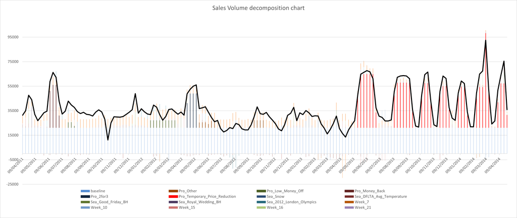

For a larger graph please find the attached spreadsheet.

## Code and other charts

### Import data

```r
library(readxl)
library(ggplot2)
data <- read_excel("./clean_data2.xlsx")

#library(scales)
#options(scipen = 200)
```

Predictor variables:

- Product data
- Promotion data
- Seasonality data
- Advertisement data

Dependent variable: - Volume

### Some possible challenges from this dataset:

1. Multi-Colinearity: When the predictors are correlated the linear model’s assumption is not satisfied and the model could be unstable.
2. Curse of Dimensionality: since there are many predictor variables for limited number of observation, the model could be overfitting easily.

### Data overview

```r
# summary(data)
```

### Checking variables

```r
# variables value all 0
var0 <- apply(data[,-c(1:2)],2,function(x) var(x,na.rm=T)==0)
cols_to_drop = c(which(var0==TRUE))   # all 0
df=data[,!(names(data) %in% names(cols_to_drop ))]

drop2 = c("Supermarket", "Date")
df2 = df[,!(names(df) %in% drop2 )]
```

### Variables correlation

```r
correl = cor(df2)
```

### First modelling

```r
mod1 <-lm(formula = Volume ~ . , data=df2)
summary(mod1)
```

```
##
## Call:
## lm(formula = Volume ~ ., data = df2)
##
## Residuals:
##     Min      1Q  Median      3Q     Max
## -7980.9 -1584.1    30.2  1973.4  7277.5
##
## Coefficients: (8 not defined because of singularities)
##                                    Estimate Std. Error t value Pr(>|t|)
## (Intercept)                       6.276e+03  4.111e+04   0.153 0.879188
## Distribution                      3.523e+02  8.829e+01   3.990 0.000185 ***
## Recommended_Selling_Price        -8.984e+03  4.920e+03  -1.826 0.072917 .
## Average_Price                     5.329e+03  3.316e+03   1.607 0.113427
## Pro_Low_Display                  -2.490e+04  3.597e+04  -0.692 0.491607
## Pro_Display                      -5.763e+03  1.438e+04  -0.401 0.689997
## Pro_Other                         3.791e+04  1.447e+04   2.620 0.011158 *
## Pro_Low_Money_Off                 6.170e+04  1.854e+04   3.327 0.001514 **
## Pro_Money_Back                    3.133e+05  4.822e+04   6.496 1.92e-08 ***
## Pro_2for3                         1.442e+05  2.144e+04   6.725 7.89e-09 ***
## Pro_Temporary_Price_Reduction     2.538e+05  1.837e+04  13.820  < 2e-16 ***
## Sea_Average_Temperature          -2.416e+03  2.089e+03  -1.157 0.252077
## Sea_Snow                          3.460e+02  6.746e+02   0.513 0.609922
## Sea_If_Snow                       3.380e+02  2.781e+03   0.122 0.903687
## Sea_Precipitation                -2.489e+02  3.800e+02  -0.655 0.514948
## Sea_Sunshine                      8.618e+02  2.205e+03   0.391 0.697352
## Sea_DFLTA_Avg_Temperature         2.906e+03  2.055e+03   1.414 0.162621
## Sea_DFLTA_Snow                   -1.610e+03  4.918e+03  -0.327 0.744470
## Sea_DFLTA_Precipitation           9.440e+02  2.584e+03   0.365 0.716179
## Sea_DFLTA_Sunshine               -8.578e+02  2.279e+03  -0.376 0.707998
## Sea_New_Years_Day                -6.761e+03  1.272e+04  -0.532 0.596954
## Sea_New_Years_BH                         NA         NA      NA       NA
## Sea_Valentines_Day                2.945e+03  1.013e+04   0.291 0.772358
## Sea_Good_Friday_BH                1.178e+04  4.185e+03   2.814 0.006636 **
## Sea_Easter_Monday_BH              3.971e+03  4.162e+03   0.954 0.343875
## Sea_Early_May_BH                  5.346e+03  4.428e+03   1.207 0.232115
## Sea_Spring_BH                    -1.897e+03  5.019e+03  -0.378 0.706734
## Sea_Summer_BH                    -8.713e+03  1.133e+04  -0.769 0.444761
## Sea_Christmas_Eve                 1.170e+04  6.965e+03   1.680 0.098175 .
## Sea_Christmas_Day                 5.979e+03  1.531e+04   0.391 0.697480
```

[output cut: 70 more lines]

```
## Media_Bacon_TV_Spend             -2.414e-01  6.350e-01  -0.380 0.705192
## Media_Press_GRPs                 -1.696e+03  1.089e+03  -1.557 0.124700
## Media_Press_Spend                 8.366e-01  7.562e-01   1.106 0.273113
## Media_Facebook_Impressions        7.521e-04  3.764e-04   1.998 0.050290 .
## Media_Facebook_Clicks            -7.806e-01  5.837e-01  -1.337 0.186258
## Media_Facebook_Spend                     NA         NA      NA       NA
## Media_TV_Sponsorship             -3.520e-02  1.380e-01  -0.255 0.799492
## Media_TVRs_Bacon_Only             1.820e+02  3.770e+01   4.828 1.02e-05 ***
## Media_TVRs_Bacon_and_Sausages     1.537e+02  7.851e+01   1.958 0.054976 .
## ---
## Signif. codes:  0 '***' 0.001 '**' 0.01 '*' 0.05 '.' 0.1 ' ' 1
##
## Residual standard error: 4352 on 59 degrees of freedom
## Multiple R-squared:  0.968,  Adjusted R-squared:  0.9137
## F-statistic: 17.83 on 100 and 59 DF,  p-value: < 2.2e-16
```

Notice: Distribution has a very significant outlier, which could cause the other variables to have misleading outcome.

Therefore we also omit Distribution variable in the model.

### Omit variables causing multicollinearity(return NA):

```r
drop3 = c("Sea_New_Years_BH", "Sea_Christmas_BH", "Sea_Boxing_Day", "Sea_Boxing_Day", "Sea_Boxing_Day_BH", "Sea_All_Bank_Holidays", "Sea_Football_WorldCup_Euros", "Week_52", "Media_Facebook_Spend", "Distribution")
df3 = df2[,!(names(df2) %in% drop3 )]

mod2 <-lm(formula = Volume ~ . , data=df3)
summary(mod2)
```

```
##
## Call:
## lm(formula = Volume ~ ., data = df3)
##
## Residuals:
##    Min     1Q Median     3Q    Max
## -12328  -1882      0   2305   7594
##
## Coefficients:
##                                    Estimate Std. Error t value Pr(>|t|)
## (Intercept)                       6.974e+04  4.237e+04   1.646  0.10498
## Recommended_Selling_Price        -1.397e+04  5.318e+03  -2.626  0.01094 *
## Average_Price                     8.208e+03  3.617e+03   2.269  0.02686 *
## Pro_Low_Display                  -2.495e+04  4.020e+04  -0.621  0.53719
## Pro_Display                      -6.848e+03  1.606e+04  -0.426  0.67145
## Pro_Other                         4.629e+04  1.600e+04   2.894  0.00530 **
## Pro_Low_Money_Off                 6.591e+04  2.069e+04   3.186  0.00229 **
## Pro_Money_Back                    3.350e+05  5.354e+04   6.256 4.57e-08 ***
## Pro_2for3                         1.577e+05  2.366e+04   6.662 9.39e-09 ***
## Pro_Temporary_Price_Reduction     2.657e+05  2.025e+04  13.118  < 2e-16 ***
## Sea_Average_Temperature          -3.683e+03  2.307e+03  -1.596  0.11570
## Sea_Snow                          2.114e+02  7.529e+02   0.281  0.77982
## Sea_If_Snow                      -4.170e+01  3.106e+03  -0.013  0.98933
## Sea_Precipitation                -5.160e+02  4.179e+02  -1.235  0.22174
## Sea_Sunshine                      6.204e+02  2.463e+03   0.252  0.80203
## Sea_DFLTA_Avg_Temperature         4.184e+03  2.268e+03   1.845  0.07003 .
## Sea_DFLTA_Snow                   -3.729e+02  5.484e+03  -0.068  0.94601
## Sea_DFLTA_Precipitation           2.718e+03  2.845e+03   0.955  0.34321
## Sea_DFLTA_Sunshine               -7.395e+02  2.547e+03  -0.290  0.77253
## Sea_New_Years_Day                -9.197e+03  1.419e+04  -0.648  0.51953
## Sea_Valentines_Day                6.398e+03  1.128e+04   0.567  0.57279
## Sea_Good_Friday_BH                1.246e+04  4.673e+03   2.666  0.00984 **
## Sea_Easter_Monday_BH              5.326e+03  4.635e+03   1.149  0.25508
## Sea_Early_May_BH                  5.636e+03  4.947e+03   1.139  0.25917
## Sea_Spring_BH                    -2.728e+03  5.603e+03  -0.487  0.62812
## Sea_Summer_BH                    -1.063e+04  1.264e+04  -0.840  0.40406
## Sea_Christmas_Eve                 1.228e+04  7.781e+03   1.578  0.11985
## Sea_Christmas_Day                 3.832e+03  1.709e+04   0.224  0.82338
## Sea_New_Years_Eve                 1.542e+04  1.104e+04   1.397  0.16747
## Sea_Royal_Wedding_BH              1.059e+04  7.708e+03   1.373  0.17479
```

[output cut: 61 more lines]

```
## Media_National_Actual_TVRs_Bacon  7.489e+02  1.468e+03   0.510  0.61181
## Media_Bacon_TV_Spend             -2.966e-01  7.095e-01  -0.418  0.67743
## Media_Press_GRPs                 -1.717e+03  1.217e+03  -1.411  0.16343
## Media_Press_Spend                 9.593e-01  8.444e-01   1.136  0.26040
## Media_Facebook_Impressions        7.642e-04  4.206e-04   1.817  0.07421 .
## Media_Facebook_Clicks            -8.869e-01  6.516e-01  -1.361  0.17857
## Media_TV_Sponsorship             -1.994e-02  1.541e-01  -0.129  0.89750
## Media_TVRs_Bacon_Only             1.772e+02  4.210e+01   4.210 8.69e-05 ***
## Media_TVRs_Bacon_and_Sausages     1.783e+02  8.747e+01   2.038  0.04596 *
## ---
## Signif. codes:  0 '***' 0.001 '**' 0.01 '*' 0.05 '.' 0.1 ' ' 1
##
## Residual standard error: 4863 on 60 degrees of freedom
## Multiple R-squared:  0.9593, Adjusted R-squared:  0.8922
## F-statistic:  14.3 on 99 and 60 DF,  p-value: < 2.2e-16
```

This model is very significant with a p-value of 2.2e-16.

The R-squared value is 0.8922, which means that the model captures 89% of the variance present in the data.

As we mentioned before, this could cause overfitting.

Therefore we

1. use stepwise selection to cut the number of variables and get a more optimal model.
2. exam variables VIF value and remove the ones with high VIF (Variance Infation Factor).

```r
library(MASS)
library(car)
step.model <- stepAIC(mod2, direction = "both", trace = FALSE)
summary(step.model)
```

```
##
## Call:
## lm(formula = Volume ~ Recommended_Selling_Price + Average_Price +
##     Pro_Other + Pro_Low_Money_Off + Pro_Money_Back + Pro_2for3 +
##     Pro_Temporary_Price_Reduction + Sea_Average_Temperature +
##     Sea_Snow + Sea_Precipitation + Sea_DFLTA_Avg_Temperature +
##     Sea_New_Years_Day + Sea_Good_Friday_BH + Sea_Easter_Monday_BH +
##     Sea_Early_May_BH + Sea_Christmas_Eve + Sea_New_Years_Eve +
##     Sea_Royal_Wedding_BH + Sea_Diamond_Jubilee_BH + Sea_2012_London_Olympics +
##     Sea_Mothers_Day + Sea_Fathers_Day + Sea_St_Patricks_Day +
##     Week_1 + Week_7 + Week_10 + Week_11 + Week_13 + Week_14 +
##     Week_15 + Week_16 + Week_17 + Week_18 + Week_19 + Week_20 +
##     Week_21 + Week_22 + Week_23 + Week_24 + Week_25 + Week_26 +
##     Week_27 + Week_28 + Week_29 + Week_30 + Week_31 + Week_32 +
##     Week_33 + Week_34 + Week_35 + Week_36 + Week_37 + Week_38 +
##     Week_39 + Week_40 + Week_41 + Week_42 + Week_43 + Week_44 +
##     Week_45 + Week_46 + Week_47 + Week_50 + Week_51 + Consumer_Confidence +
##     Horse_Meat_Scandal + Media_National_Actual_TVRs_Bacon + Media_Press_GRPs +
##     Media_Press_Spend + Media_Facebook_Impressions + Media_Facebook_Clicks +
##     Media_TVRs_Bacon_Only + Media_TVRs_Bacon_and_Sausages, data = df3)
##
## Residuals:
##    Min     1Q Median     3Q    Max
## -13118  -1948      0   2104   7152
##
## Coefficients:
##                                    Estimate Std. Error t value Pr(>|t|)
## (Intercept)                       7.113e+04  1.443e+04   4.929 3.97e-06 ***
## Recommended_Selling_Price        -1.308e+04  3.839e+03  -3.406 0.001004 **
## Average_Price                     7.861e+03  2.703e+03   2.908 0.004624 **
## Pro_Other                         4.455e+04  1.182e+04   3.770 0.000299 ***
## Pro_Low_Money_Off                 6.270e+04  1.437e+04   4.363 3.55e-05 ***
## Pro_Money_Back                    3.098e+05  3.093e+04  10.014 4.27e-16 ***
## Pro_2for3                         1.605e+05  1.857e+04   8.645 2.60e-13 ***
## Pro_Temporary_Price_Reduction     2.563e+05  1.465e+04  17.491  < 2e-16 ***
## Sea_Average_Temperature          -4.277e+03  1.028e+03  -4.162 7.47e-05 ***
## Sea_Snow                          1.422e+02  8.570e+01   1.659 0.100664
## Sea_Precipitation                -1.036e+02  5.300e+01  -1.955 0.053824 .
## Sea_DFLTA_Avg_Temperature         4.827e+03  1.028e+03   4.696 9.96e-06 ***
## Sea_New_Years_Day                -1.508e+04  7.641e+03  -1.974 0.051592 .
```

[output cut: 52 more lines]

```
## Consumer_Confidence              -1.216e+02  8.887e+01  -1.368 0.174867
## Horse_Meat_Scandal                9.716e+01  4.071e+01   2.387 0.019184 *
## Media_National_Actual_TVRs_Bacon  1.194e+02  4.355e+01   2.740 0.007462 **
## Media_Press_GRPs                 -1.730e+03  1.054e+03  -1.642 0.104266
## Media_Press_Spend                 9.526e-01  7.412e-01   1.285 0.202143
## Media_Facebook_Impressions        6.122e-04  3.207e-04   1.909 0.059603 .
## Media_Facebook_Clicks            -7.669e-01  5.034e-01  -1.524 0.131283
## Media_TVRs_Bacon_Only             1.545e+02  3.179e+01   4.861 5.20e-06 ***
## Media_TVRs_Bacon_and_Sausages     1.733e+02  5.355e+01   3.236 0.001721 **
## ---
## Signif. codes:  0 '***' 0.001 '**' 0.01 '*' 0.05 '.' 0.1 ' ' 1
##
## Residual standard error: 4313 on 86 degrees of freedom
## Multiple R-squared:  0.9541, Adjusted R-squared:  0.9152
## F-statistic: 24.51 on 73 and 86 DF,  p-value: < 2.2e-16
```

```r
VIF_step=vif(step.model) # very high vif for some variables
```

To avoid multicollinearity, we examine variables VIF value, omit the ones with very high VIF.

```r
# model that omitted variables with very high vif
mod3=lm(formula = Volume ~ Average_Price +
    Pro_Other + Pro_Low_Money_Off + Pro_Money_Back +
    Pro_2for3 + Pro_Temporary_Price_Reduction + Sea_Snow + Sea_Precipitation + Sea_DFLTA_Avg_Temperature +
    Sea_Good_Friday_BH + Sea_Easter_Monday_BH +
    Sea_Early_May_BH + Sea_Christmas_Eve + Sea_New_Years_Eve +
    Sea_Royal_Wedding_BH + Sea_Diamond_Jubilee_BH + Sea_2012_London_Olympics +
    Sea_Mothers_Day + Sea_St_Patricks_Day +
    Week_1 + Week_7 + Week_10 + Week_11 + Week_13 + Week_14 +
    Week_15 + Week_16 + Week_17 + Week_18 + Week_19 + Week_20 +
    Week_21 + Week_22 + Week_23 + Week_24 + Week_26 +
    Week_27 + Week_28 + Week_29 + Week_30 + Week_31 + Week_32 +
    Week_33 + Week_34 + Week_35 + Week_36 + Week_37 + Week_38 +
    Week_39 + Week_40 + Week_41 + Week_42 + Week_43 + Week_44 +
    Week_45 + Week_46 + Week_47 + Week_50 + Week_51  + Consumer_Confidence +
    Horse_Meat_Scandal + Media_National_Actual_TVRs_Bacon + Media_Press_GRPs +
    Media_Facebook_Impressions + Media_Facebook_Clicks +
    Media_TVRs_Bacon_Only + Media_TVRs_Bacon_and_Sausages, data = df3)
summary(mod3)
```

```
##
## Call:
## lm(formula = Volume ~ Average_Price + Pro_Other + Pro_Low_Money_Off +
##     Pro_Money_Back + Pro_2for3 + Pro_Temporary_Price_Reduction +
##     Sea_Snow + Sea_Precipitation + Sea_DFLTA_Avg_Temperature +
##     Sea_Good_Friday_BH + Sea_Easter_Monday_BH + Sea_Early_May_BH +
##     Sea_Christmas_Eve + Sea_New_Years_Eve + Sea_Royal_Wedding_BH +
##     Sea_Diamond_Jubilee_BH + Sea_2012_London_Olympics + Sea_Mothers_Day +
##     Sea_St_Patricks_Day + Week_1 + Week_7 + Week_10 + Week_11 +
##     Week_13 + Week_14 + Week_15 + Week_16 + Week_17 + Week_18 +
##     Week_19 + Week_20 + Week_21 + Week_22 + Week_23 + Week_24 +
##     Week_26 + Week_27 + Week_28 + Week_29 + Week_30 + Week_31 +
##     Week_32 + Week_33 + Week_34 + Week_35 + Week_36 + Week_37 +
##     Week_38 + Week_39 + Week_40 + Week_41 + Week_42 + Week_43 +
##     Week_44 + Week_45 + Week_46 + Week_47 + Week_50 + Week_51 +
##     Consumer_Confidence + Horse_Meat_Scandal + Media_National_Actual_TVRs_Bacon +
##     Media_Press_GRPs + Media_Facebook_Impressions + Media_Facebook_Clicks +
##     Media_TVRs_Bacon_Only + Media_TVRs_Bacon_and_Sausages, data = df3)
##
## Residuals:
##      Min       1Q   Median       3Q      Max
## -15177.6  -2316.1    157.2   2640.3   8602.5
##
## Coefficients:
##                                    Estimate Std. Error t value Pr(>|t|)
## (Intercept)                       1.678e+04  1.116e+04   1.504 0.135977
## Average_Price                     4.444e+02  2.014e+03   0.221 0.825834
## Pro_Other                         2.110e+04  1.194e+04   1.767 0.080601 .
## Pro_Low_Money_Off                 4.291e+04  1.583e+04   2.712 0.007989 **
## Pro_Money_Back                    2.895e+05  3.353e+04   8.635 1.70e-13 ***
## Pro_2for3                         1.325e+05  2.011e+04   6.590 2.71e-09 ***
## Pro_Temporary_Price_Reduction     2.216e+05  1.276e+04  17.361  < 2e-16 ***
## Sea_Snow                          2.050e+02  9.748e+01   2.103 0.038176 *
## Sea_Precipitation                -1.635e+01  5.971e+01  -0.274 0.784870
## Sea_DFLTA_Avg_Temperature         8.179e+02  3.073e+02   2.661 0.009185 **
## Sea_Good_Friday_BH                9.218e+03  3.705e+03   2.488 0.014653 *
## Sea_Easter_Monday_BH             -3.203e+02  3.944e+03  -0.081 0.935448
## Sea_Early_May_BH                  4.079e+03  4.759e+03   0.857 0.393612
## Sea_Christmas_Eve                 4.288e+03  3.394e+03   1.264 0.209539
## Sea_New_Years_Eve                 2.103e+03  3.627e+03   0.580 0.563522
```

[output cut: 44 more lines]

```
## Week_51                           1.705e+03  5.766e+02   2.957 0.003942 **
## Consumer_Confidence              -2.470e+02  8.670e+01  -2.849 0.005408 **
## Horse_Meat_Scandal                5.069e+01  4.660e+01   1.088 0.279565
## Media_National_Actual_TVRs_Bacon  1.019e+02  5.077e+01   2.008 0.047613 *
## Media_Press_GRPs                 -1.232e+03  3.721e+02  -3.311 0.001327 **
## Media_Facebook_Impressions        6.555e-04  3.755e-04   1.746 0.084190 .
## Media_Facebook_Clicks            -1.072e+00  5.883e-01  -1.823 0.071581 .
## Media_TVRs_Bacon_Only             1.191e+02  3.467e+01   3.436 0.000889 ***
## Media_TVRs_Bacon_and_Sausages     4.883e+01  5.495e+01   0.889 0.376489
## ---
## Signif. codes:  0 '***' 0.001 '**' 0.01 '*' 0.05 '.' 0.1 ' ' 1
##
## Residual standard error: 5098 on 92 degrees of freedom
## Multiple R-squared:  0.9315, Adjusted R-squared:  0.8815
## F-statistic: 18.66 on 67 and 92 DF,  p-value: < 2.2e-16
```

```r
vif(mod3)
```

```
##                    Average_Price                        Pro_Other
##                         5.359752                         2.906490
##                Pro_Low_Money_Off                   Pro_Money_Back
##                         2.593703                         1.811919
##                        Pro_2for3    Pro_Temporary_Price_Reduction
##                         2.666343                         4.427767
##                         Sea_Snow                Sea_Precipitation
##                         1.781271                         2.148949
##        Sea_DFLTA_Avg_Temperature               Sea_Good_Friday_BH
##                         2.099364                         2.060018
##             Sea_Easter_Monday_BH                 Sea_Early_May_BH
##                         2.333819                         2.564993
##                Sea_Christmas_Eve                Sea_New_Years_Eve
##                         1.304241                         1.490160
##             Sea_Royal_Wedding_BH           Sea_Diamond_Jubilee_BH
##                         1.861181                         2.285147
##         Sea_2012_London_Olympics                  Sea_Mothers_Day
##                         1.601208                         1.872164
##              Sea_St_Patricks_Day                           Week_1
##                         2.533076                         1.792557
##                           Week_7                          Week_10
##                         1.547260                         1.305257
##                          Week_11                          Week_13
##                         2.908737                         1.508987
##                          Week_14                          Week_15
##                         2.121466                         1.888862
##                          Week_16                          Week_17
##                         1.932766                         1.971847
##                          Week_18                          Week_19
##                         1.639694                         2.498770
##                          Week_20                          Week_21
##                         1.290195                         1.447058
##                          Week_22                          Week_23
##                         1.398513                         2.592348
##                          Week_24                          Week_26
##                         1.513554                         1.449708
##                          Week_27                          Week_28
##                         1.460568                         1.386953
##                          Week_29                          Week_30
##                         1.297875                         1.194564
```

[output cut: 13 more lines]

```
##                         1.185419                         1.215711
##                          Week_45                          Week_46
##                         1.216409                         1.256294
##                          Week_47                          Week_50
##                         1.196578                         1.191676
##                          Week_51              Consumer_Confidence
##                         1.435815                         3.676918
##               Horse_Meat_Scandal Media_National_Actual_TVRs_Bacon
##                         2.159763                         2.234029
##                 Media_Press_GRPs       Media_Facebook_Impressions
##                         1.661422                         4.037072
##            Media_Facebook_Clicks            Media_TVRs_Bacon_Only
##                         3.835558                         1.364857
##    Media_TVRs_Bacon_and_Sausages
##                         1.840554
```

```r
step.model2 <- stepAIC(mod3, direction = "both", trace = FALSE)
summary(step.model2)
```

```
##
## Call:
## lm(formula = Volume ~ Pro_Other + Pro_Low_Money_Off + Pro_Money_Back +
##     Pro_2for3 + Pro_Temporary_Price_Reduction + Sea_Snow + Sea_DFLTA_Avg_Temperature +
##     Sea_Good_Friday_BH + Sea_Royal_Wedding_BH + Sea_2012_London_Olympics +
##     Week_7 + Week_10 + Week_15 + Week_16 + Week_21 + Week_22 +
##     Week_31 + Week_32 + Week_47 + Week_51 + Consumer_Confidence +
##     Media_National_Actual_TVRs_Bacon + Media_Press_GRPs + Media_Facebook_Impressions +
##     Media_Facebook_Clicks + Media_TVRs_Bacon_Only, data = df3)
##
## Residuals:
##      Min       1Q   Median       3Q      Max
## -16857.1  -2472.2    135.1   2998.0   8111.6
##
## Coefficients:
##                                    Estimate Std. Error t value Pr(>|t|)
## (Intercept)                       2.119e+04  1.573e+03  13.475  < 2e-16 ***
## Pro_Other                         2.214e+04  6.839e+03   3.238 0.001522 **
## Pro_Low_Money_Off                 3.503e+04  1.013e+04   3.458 0.000732 ***
## Pro_Money_Back                    2.835e+05  2.436e+04  11.640  < 2e-16 ***
## Pro_2for3                         1.249e+05  1.194e+04  10.463  < 2e-16 ***
## Pro_Temporary_Price_Reduction     2.167e+05  8.336e+03  25.995  < 2e-16 ***
## Sea_Snow                          2.261e+02  7.415e+01   3.049 0.002769 **
## Sea_DFLTA_Avg_Temperature         7.981e+02  2.255e+02   3.539 0.000554 ***
## Sea_Good_Friday_BH                8.596e+03  2.645e+03   3.250 0.001460 **
## Sea_Royal_Wedding_BH              1.602e+04  4.603e+03   3.481 0.000676 ***
## Sea_2012_London_Olympics         -1.593e+03  5.638e+02  -2.826 0.005439 **
## Week_7                           -9.171e+02  5.146e+02  -1.782 0.076983 .
## Week_10                          -1.002e+03  4.780e+02  -2.097 0.037903 *
## Week_15                           1.083e+03  4.406e+02   2.458 0.015270 *
## Week_16                           6.086e+02  4.701e+02   1.295 0.197635
## Week_21                           7.722e+02  4.695e+02   1.645 0.102404
## Week_22                           8.701e+02  4.725e+02   1.842 0.067770 .
## Week_31                           7.617e+02  4.841e+02   1.573 0.118034
## Week_32                           8.290e+02  4.848e+02   1.710 0.089580 .
## Week_47                          -6.324e+02  4.364e+02  -1.449 0.149649
## Week_51                           1.727e+03  4.435e+02   3.893 0.000156 ***
## Consumer_Confidence              -2.234e+02  5.984e+01  -3.733 0.000279 ***
## Media_National_Actual_TVRs_Bacon  8.580e+01  3.637e+01   2.359 0.019762 *
## Media_Press_GRPs                 -1.268e+03  2.984e+02  -4.248 4.03e-05 ***
## Media_Facebook_Impressions        5.222e-04  2.783e-04   1.877 0.062770 .
## Media_Facebook_Clicks            -8.979e-01  4.791e-01  -1.874 0.063095 .
## Media_TVRs_Bacon_Only             9.792e+01  2.924e+01   3.349 0.001054 **
## ---
## Signif. codes:  0 '***' 0.001 '**' 0.01 '*' 0.05 '.' 0.1 ' ' 1
##
## Residual standard error: 4557 on 133 degrees of freedom
## Multiple R-squared:  0.9208, Adjusted R-squared:  0.9054
## F-statistic: 59.51 on 26 and 133 DF,  p-value: < 2.2e-16
```

```r
VIF_step=vif(step.model2) # very high vif for some variables
```

Notice: the price variable has been removed because the promotion variables are able to provide the information it has.

We will provide more in-depth analysis into these variables.

### Model Evaluation

```r
#plot(mod2)
#plot(mod3)
```

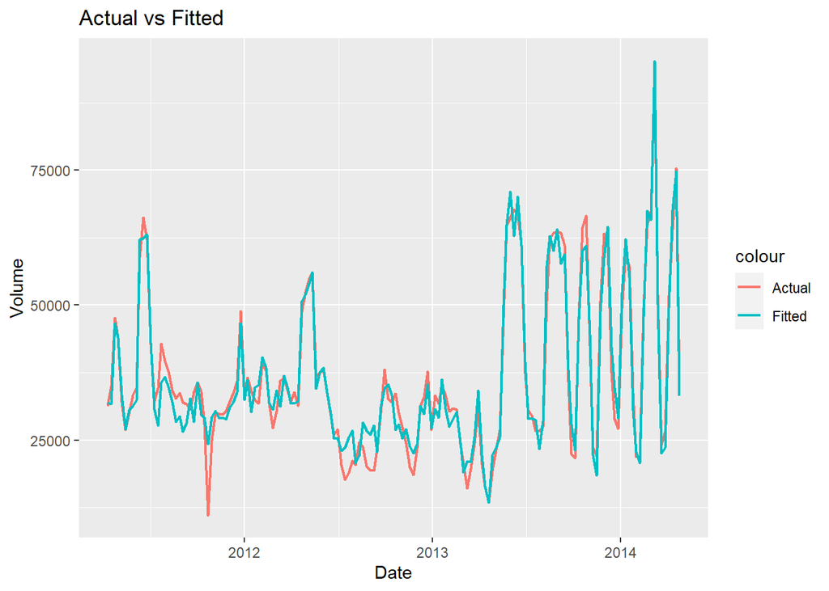

```r
data2=data
data2$fitted=fitted(step.model)

ggplot(data2, aes(Date)) +
  geom_line(aes(y = Volume, colour = "Actual"),size=0.8) +
  geom_line(aes(y = fitted, colour = "Fitted"),size=0.8)+
  labs(x ="Date",y ="Volume")+ ggtitle("Actual vs Fitted")
```

```r
rmse2=sqrt(mean((data2$fitted - data$Volume)^2)) #rmse for ols
mae2=sum(abs(as.numeric(data$Volume)-as.numeric(data2$fitted)))/length(data$Volume)  #mae
aic2=AIC(step.model)

print(paste('RMSE for Model 2:', rmse2))
```

```
## [1] "RMSE for Model 2: 3162.17315819818"
```

```r
print(paste('MAE for Model 2:', mae2))
```

```
## [1] "MAE for Model 2: 2430.1551467519"
```

```r
print(paste('AIC for Model 2:', aic2))
```

```
## [1] "AIC for Model 2: 3182.94505974823"
```

```r
print(paste('R-squared for Model 2:', summary(step.model)$adj.r.squared))
```

```
## [1] "R-squared for Model 2: 0.915222157066361"
```

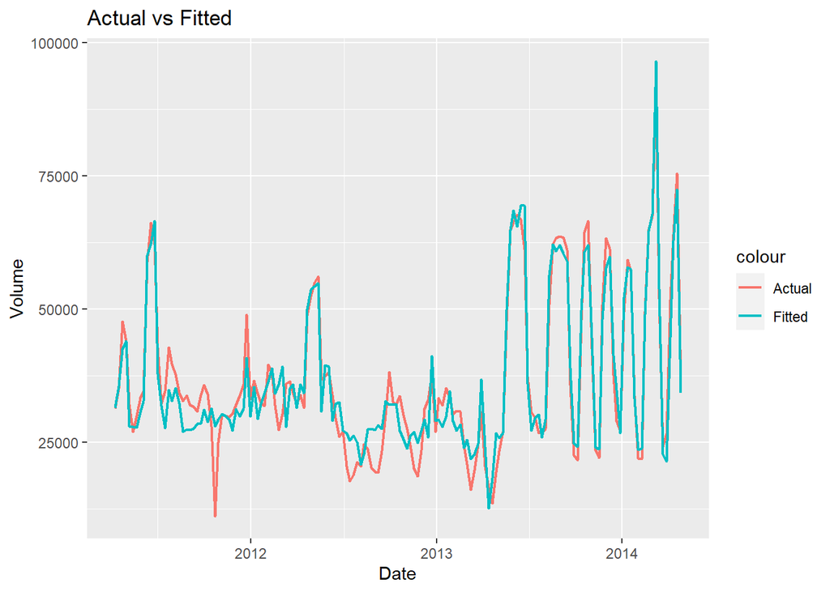

```r
data3=data
data3$fitted=fitted(step.model2)

ggplot(data3, aes(Date)) +
  geom_line(aes(y = Volume, colour = "Actual"),size=0.8) +
  geom_line(aes(y = fitted, colour = "Fitted"),size=0.8)+
  labs(x ="Date",y ="Volume") + ggtitle("Actual vs Fitted")
```

```r
rmse3=sqrt(mean((data3$fitted - data$Volume)^2)) #rmse for ols
mae3=sum(abs(as.numeric(data$Volume)-as.numeric(data3$fitted)))/length(data$Volume)  #mae
aic3=AIC(step.model2)

print(paste('RMSE for Model 3:', rmse3))
```

```
## [1] "RMSE for Model 3: 4154.68864589006"
```

```r
print(paste('MAE for Model 3:', mae3))
```

```
## [1] "MAE for Model 3: 3275.54258973906"
```

```r
print(paste('AIC for Model 3:', aic3))
```

```
## [1] "AIC for Model 3: 3176.29801692244"
```

```r
print(paste('R-squared for Model 3:', summary(step.model2)$adj.r.squared))
```

```
## [1] "R-squared for Model 3: 0.905368691982243"
```

### Sales decomposition chart

```r
baseline=step.model2$coefficients[1]
Pro_Other=step.model2$coefficients[2]*df3$Pro_Other
Pro_Low_Money_Off=step.model2$coefficients[3]*df3$Pro_Low_Money_Off
Pro_Money_Back=step.model2$coefficients[4]*df3$Pro_Money_Back
Pro_2for3=step.model2$coefficients[5]*df3$Pro_2for3
Pro_Temporary_Price_Reduction=step.model2$coefficients[6]*df3$Pro_Temporary_Price_Reduction

Sea_Snow=step.model2$coefficients[7]*df3$Sea_Snow
Sea_DFLTA_Avg_Temperature=step.model2$coefficients[8]*df3$Sea_DFLTA_Avg_Temperature
Sea_Good_Friday_BH=step.model2$coefficients[9]*df3$Sea_Good_Friday_BH
Sea_Royal_Wedding_BH=step.model2$coefficients[10]*df3$Sea_Royal_Wedding_BH
Sea_2012_London_Olympics=step.model2$coefficients[11]*df3$Sea_2012_London_Olympics

Week_7=step.model2$coefficients[12]*df3$Week_7
Week_10=step.model2$coefficients[13]*df3$Week_10
Week_15=step.model2$coefficients[14]*df3$Week_15
Week_16=step.model2$coefficients[15]*df3$Week_16
Week_21=step.model2$coefficients[16]*df3$Week_21
Week_22=step.model2$coefficients[17]*df3$Week_22
Week_31=step.model2$coefficients[18]*df3$Week_31
Week_32=step.model2$coefficients[19]*df3$Week_32
Week_47=step.model2$coefficients[20]*df3$Week_47
Week_51=step.model2$coefficients[21]*df3$Week_51

Consumer_Confidence=step.model2$coefficients[22]*df3$Consumer_Confidence
Media_National_Actual_TVRs_Bacon=step.model2$coefficients[23]*df3$Media_National_Actual_TVRs_Bacon
Media_Press_GRPs=step.model2$coefficients[24]*df3$Media_Press_GRPs
Media_Facebook_Impressions=step.model2$coefficients[25]*df3$Media_Facebook_Impressions
Media_Facebook_Clicks=step.model2$coefficients[26]*df3$Media_Facebook_Clicks
Media_TVRs_Bacon_Only=step.model2$coefficients[27]*df3$Media_TVRs_Bacon_Only

df <- data.frame(baseline, Pro_Other,Pro_Low_Money_Off , Pro_Money_Back, Pro_2for3 ,Pro_Temporary_Price_Reduction ,
                 Sea_Snow,Sea_DFLTA_Avg_Temperature , Sea_Good_Friday_BH,Sea_Royal_Wedding_BH ,Sea_2012_London_Olympics,
                 Week_7, Week_10, Week_15,Week_16 , Week_21,Week_22 , Week_31,Week_32 ,Week_47,Week_51,
                 Consumer_Confidence,Media_National_Actual_TVRs_Bacon ,Media_Press_GRPs , Media_Facebook_Impressions, Media_Facebook_Clicks, Media_TVRs_Bacon_Only)
df$Date=data$Date
df$Volume=data$Volume
library(openxlsx)
write.xlsx(df,  "~/Job/Brightblue consulting/project/Decomposition.xlsx", sheetName="Sheet1",
  col.names=TRUE, row.names=TRUE, append=FALSE)
```

### More analysis into variables

#### target variable - volume

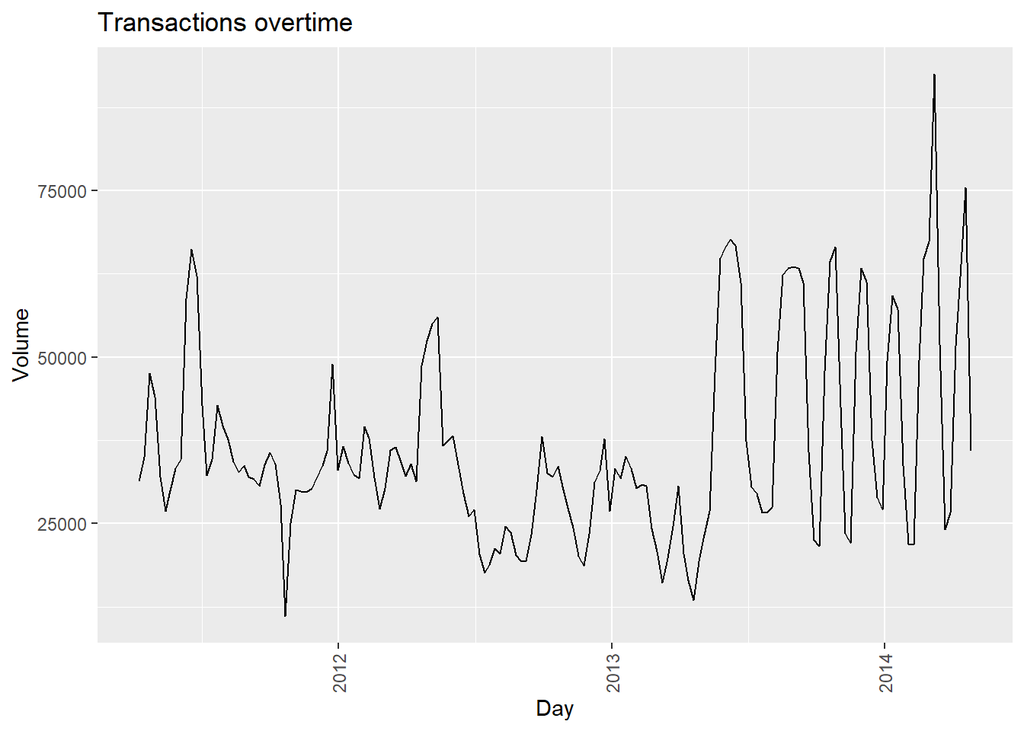

```r
library(ggplot2)
ggplot(data,aes(x =Date,y =Volume)) +
  geom_line() +
  labs(x ="Day",y ="Volume",title ="Transactions overtime")+
  theme(axis.text.x =element_text(angle =90,vjust =0.5))
```

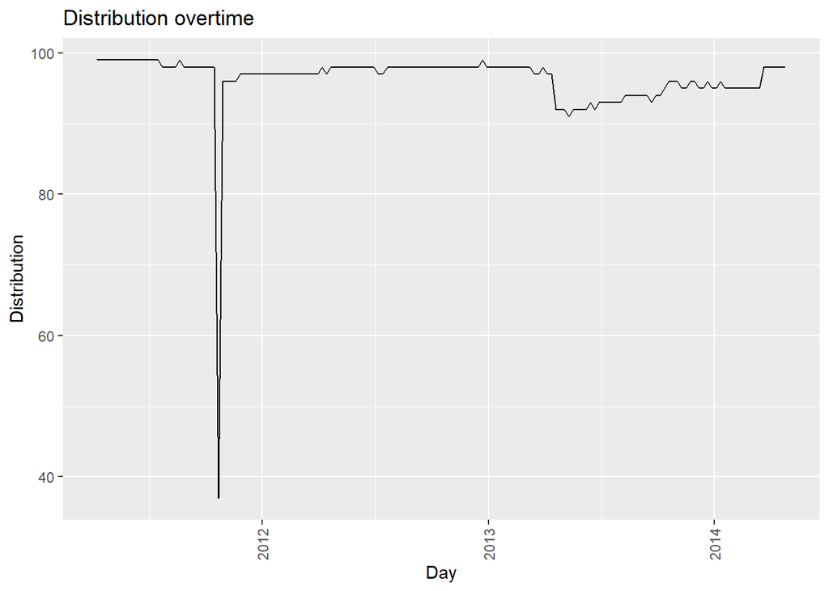

```r
ggplot(data,aes(x =Date,y =Distribution)) +
  geom_line() +
  labs(x ="Day",y ="Distribution",title ="Distribution overtime")+
  theme(axis.text.x =element_text(angle =90,vjust =0.5))
```

For a model with all initial variables, distribution would be a very significant variable.  
But this is because of the significant drop in 2011, which led to drop in volume.

#### Predictor - price

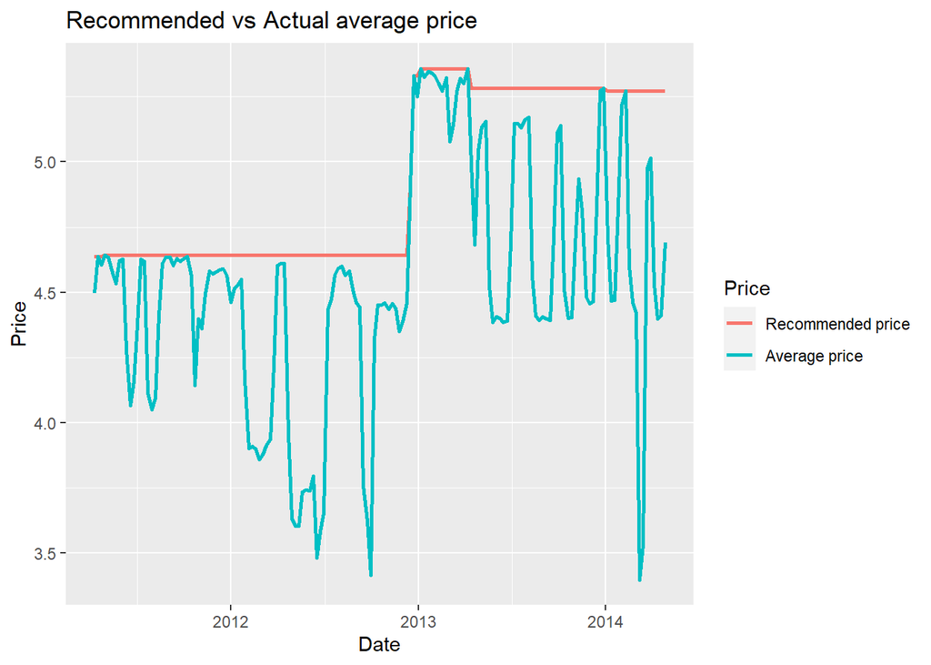

```r
ggplot()+
    geom_line(data=data,aes(y=Recommended_Selling_Price,x= Date,colour="darkblue"),size=1 )+
    geom_line(data=data,aes(y=Average_Price,x= Date,colour="red"),size=1) +
    scale_color_discrete(name = "Price", labels = c("Recommended price", "Average price"))+
  labs(x ="Date",y ="Price") + ggtitle("Recommended vs Actual average price")
```

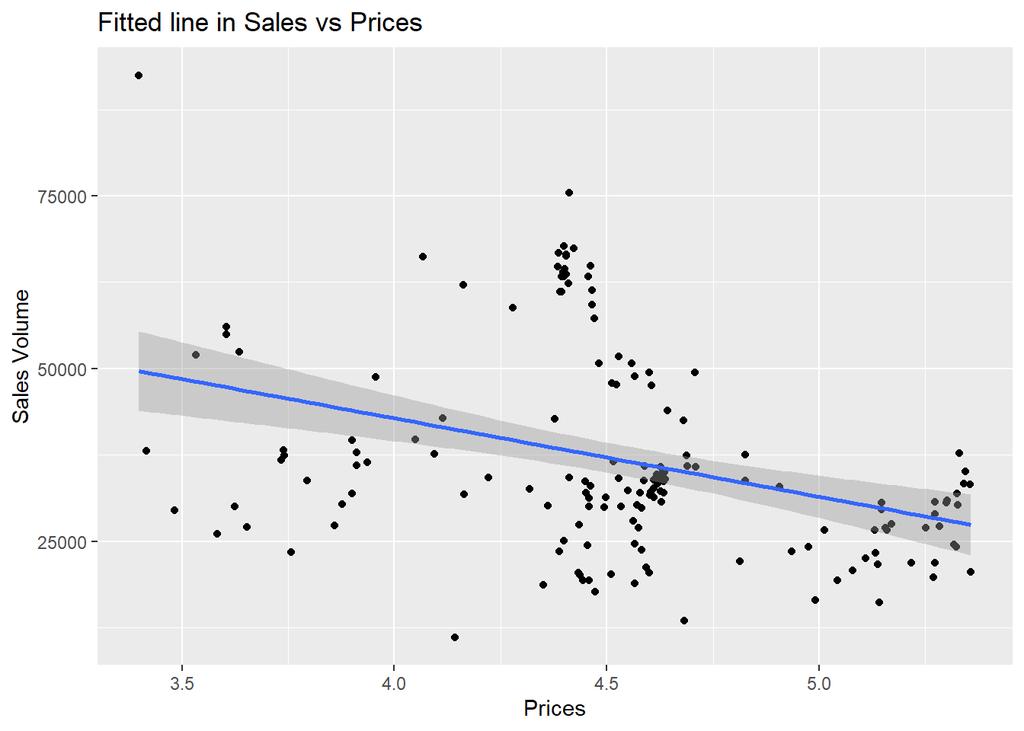

```r
ggplot(data, aes(x=Average_Price, y=(Volume))) +  geom_point() +  geom_smooth(method=lm, formula = y ~ x) +
  xlab("Prices") + ylab("Sales Volume") +ggtitle("Fitted line in Sales vs Prices")
```

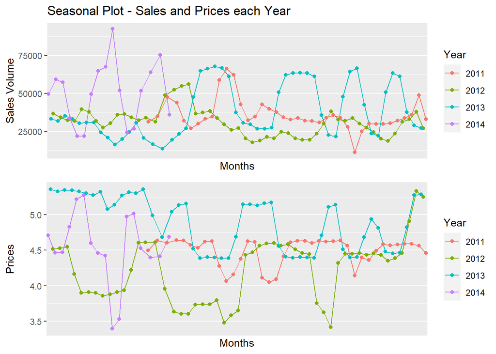

```r
###Seasonal Plot - Sales per year
dt=data
dt$Year <- as.factor(format(dt$Date, "%Y"))
#to use as actual values in x-axis
dt$MonthWeek <- format(dt$Date, "%m-%d")

##create breaks & labels by first sorting thee data frame because all month dates are sorted in plot
library(plyr)
dt_sorted <- arrange(dt, MonthWeek)
breaks <- dt_sorted[seq(1,length(dt_sorted$MonthWeek)),"MonthWeek"]


library("gridExtra")
p1 <- ggplot(dt, aes(MonthWeek, Volume)) + geom_line(aes(group=Year,  colour=Year)) + geom_point(aes(group=Year, colour=Year)) + xlab("Months") + ylab("Sales Volume") + ggtitle("Seasonal Plot - Sales and Prices each Year") + scale_x_discrete(breaks = breaks, labels = labels)
p2 <- ggplot(dt, aes(MonthWeek, Average_Price)) + geom_line(aes(group=Year,  colour=Year)) + geom_point(aes(group=Year, colour=Year)) + xlab("Months") + ylab("Prices\n") + scale_x_discrete(breaks = breaks, labels = labels)
grid.arrange(p1,p2)
```

#### Predictor - promotion

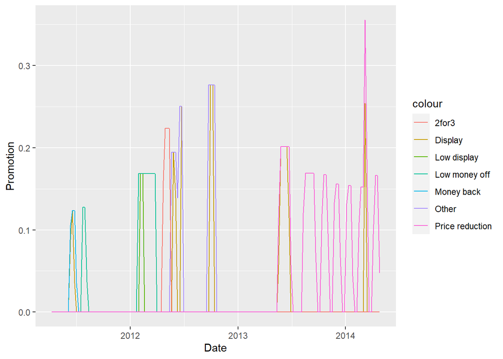

```r
ggplot(data, aes(Date)) +
  geom_line(aes(y = Pro_Low_Display, colour = "Low display"),size=0.5) +
  geom_line(aes(y = Pro_Display, colour = "Display"),size=0.5)+
  geom_line(aes(y = Pro_Other, colour = "Other"),size=0.5)+
  geom_line(aes(y = Pro_Low_Money_Off, colour = "Low money off"),size=0.5) +
  geom_line(aes(y = Pro_Money_Back, colour = "Money back"),size=0.5)+
  geom_line(aes(y = Pro_2for3, colour = "2for3"),size=0.5)+
  geom_line(aes(y = Pro_Temporary_Price_Reduction, colour = "Price reduction"),size=0.5)+
  labs(x ="Date",y ="Promotion")
```

The OLS model shows that all promotion are quite important for sales volume, especially: Low_Money_Off， Money_Back，2for3 and Temporary_Price_Reduction.  
They all have positive relationship with sales volume, which means more promotion leads to higher sales volume.

#### Predictor - Media spend

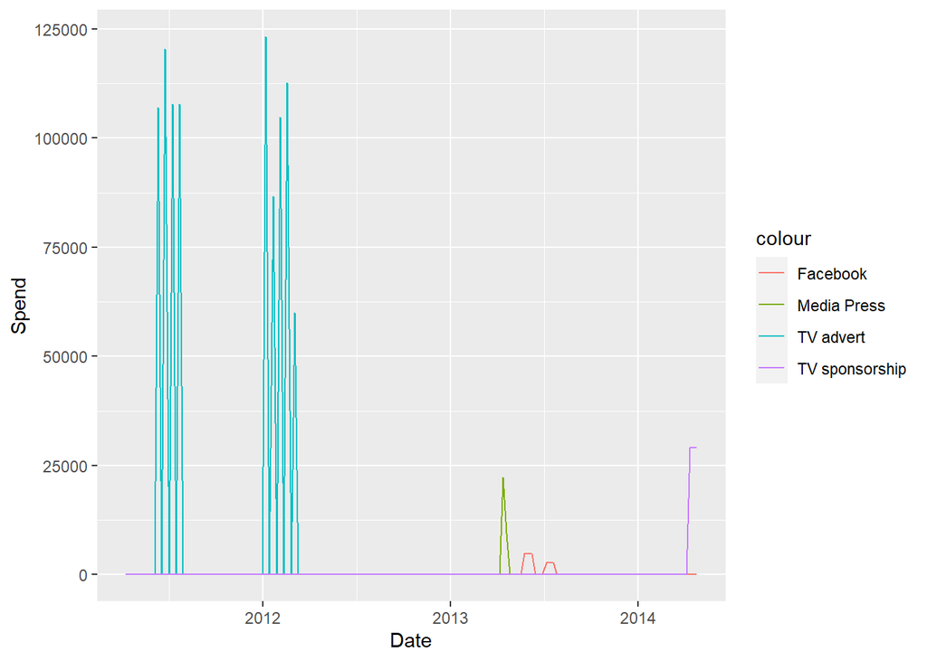

```r
ggplot(data, aes(Date)) +
  geom_line(aes(y = Media_Bacon_TV_Spend, colour = "TV advert"),size=0.5) +
  geom_line(aes(y = Media_Press_Spend, colour = "Media Press"),size=0.5)+
  geom_line(aes(y = Media_Facebook_Spend, colour = "Facebook"),size=0.5)+
  geom_line(aes(y = Media_TV_Sponsorship, colour = "TV sponsorship"),size=0.5) +
  labs(x ="Date",y ="Spend")
```

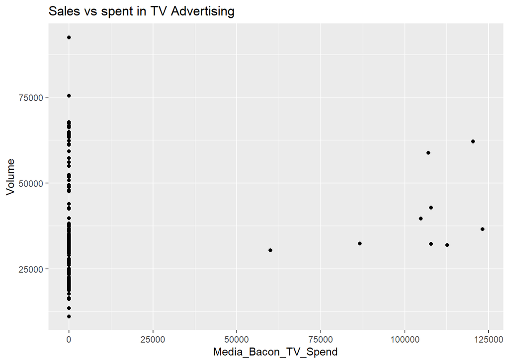

```r
library(ggplot2)
ggplot(data, aes(Media_Bacon_TV_Spend,Volume)) + geom_point() + ggtitle("Sales vs spent in TV Advertising")
```

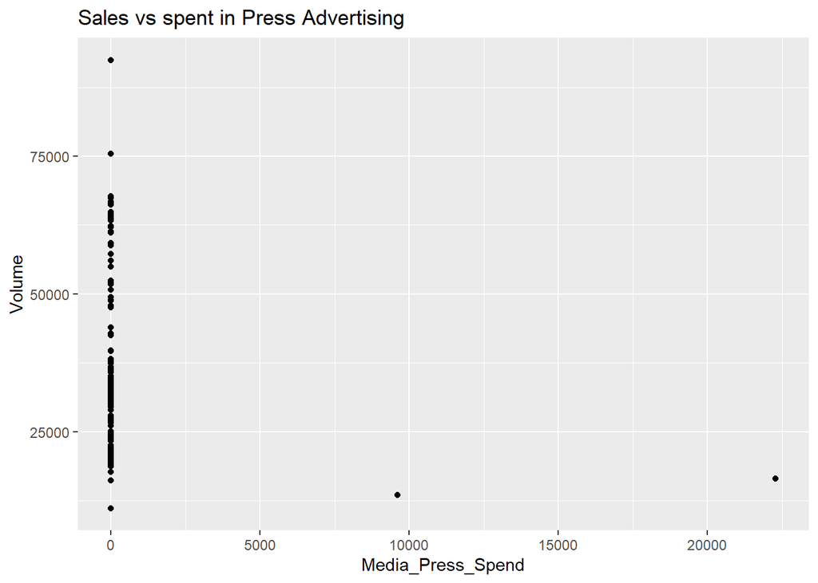

```r
ggplot(data, aes(Media_Press_Spend,Volume)) + geom_point() + ggtitle("Sales vs spent in Press Advertising")
```

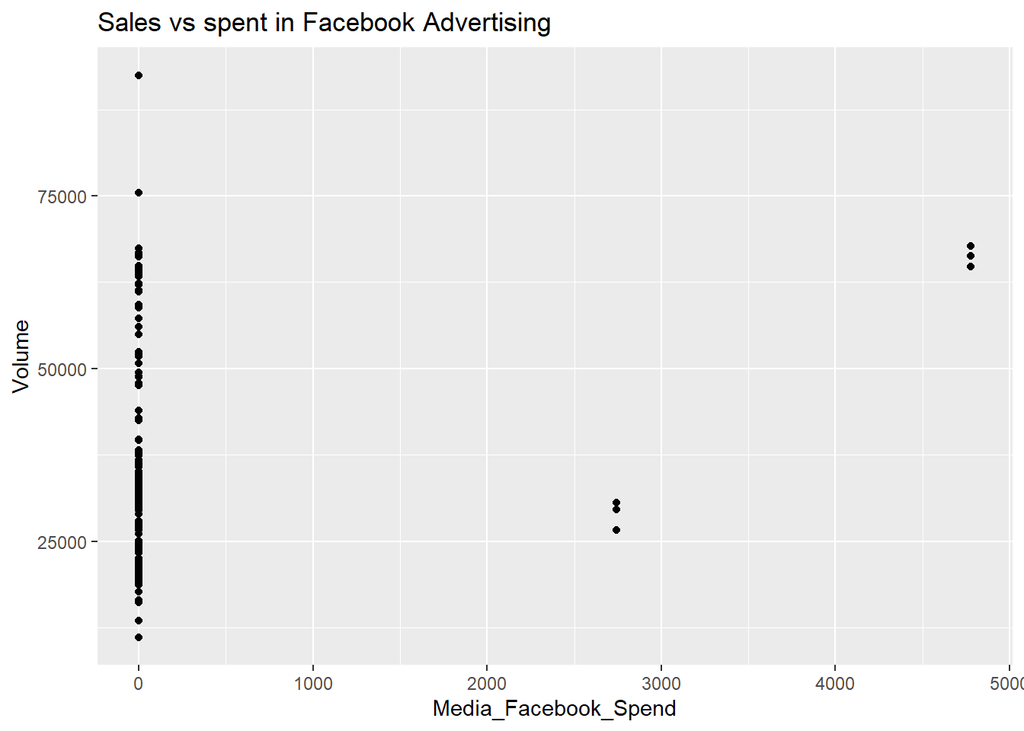

```r
ggplot(data, aes(Media_Facebook_Spend,Volume)) + geom_point() + ggtitle("Sales vs spent in Facebook Advertising")
```

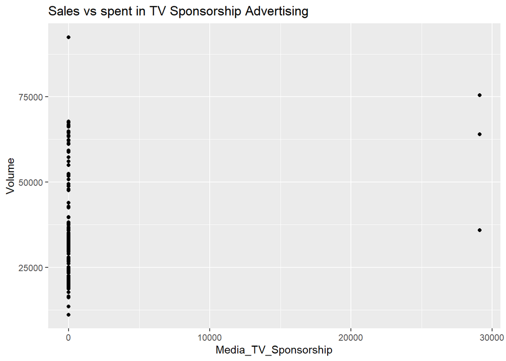

```r
ggplot(data, aes(Media_TV_Sponsorship,Volume)) + geom_point() + ggtitle("Sales vs spent in TV Sponsorship Advertising")
```

For media advertisement, within the significant ones:

1. Percentage of target audience who viewed the Television advert & Percentage of target audience who viewed the Television advert for the peacekeeper campaign for the 30 second advert has positive correlation with sales volume.
2. Percentage of audience who viewed the newspaper(press) advert has negative correlation with sales volume.

This might indicate a positive effect from TV advertisement, and a negative effect from press advert. However, the data for advertisement is relatively limited.  
If we could include variable of Value of modelled uplift for each channel, we can calculate the ROI for each advert channel to see which one provides the highest return on investment.